# Risk Factor Analysis

## Outcome Variable

**Outcome Variable:** y_rate_len

## Predictor Variables

**Intervention Variable:** single

**Adjustment Set:**

unadjusted

## Stratifying Variables

The analysis was stratified on these variable(s):

- agecat
- studyid
- country

## Data Summary

| agecat | studyid | country | single | n_cell | n |
| --- | --- | --- | --- | --- | --- |
| 0-3 months | ki0047075b-MAL-ED | BANGLADESH | 0 | 243 | 243 |
| 0-3 months | ki0047075b-MAL-ED | BANGLADESH | 1 | 0 | 243 |
| 0-3 months | ki0047075b-MAL-ED | BRAZIL | 0 | 145 | 168 |
| 0-3 months | ki0047075b-MAL-ED | BRAZIL | 1 | 23 | 168 |
| 0-3 months | ki0047075b-MAL-ED | INDIA | 0 | 182 | 182 |
| 0-3 months | ki0047075b-MAL-ED | INDIA | 1 | 0 | 182 |
| 0-3 months | ki0047075b-MAL-ED | NEPAL | 0 | 156 | 156 |
| 0-3 months | ki0047075b-MAL-ED | NEPAL | 1 | 0 | 156 |
| 0-3 months | ki0047075b-MAL-ED | PERU | 0 | 234 | 265 |
| 0-3 months | ki0047075b-MAL-ED | PERU | 1 | 31 | 265 |
| 0-3 months | ki0047075b-MAL-ED | SOUTH AFRICA | 0 | 122 | 211 |
| 0-3 months | ki0047075b-MAL-ED | SOUTH AFRICA | 1 | 89 | 211 |
| 0-3 months | ki0047075b-MAL-ED | TANZANIA, UNITED REPUBLIC OF | 0 | 219 | 228 |
| 0-3 months | ki0047075b-MAL-ED | TANZANIA, UNITED REPUBLIC OF | 1 | 9 | 228 |
| 0-3 months | ki1119695-PROBIT | BELARUS | 0 | 7264 | 7539 |
| 0-3 months | ki1119695-PROBIT | BELARUS | 1 | 275 | 7539 |
| 0-3 months | ki1126311-ZVITAMBO | ZIMBABWE | 0 | 7453 | 7953 |
| 0-3 months | ki1126311-ZVITAMBO | ZIMBABWE | 1 | 500 | 7953 |
| 0-3 months | ki1135781-COHORTS | GUATEMALA | 0 | 300 | 328 |
| 0-3 months | ki1135781-COHORTS | GUATEMALA | 1 | 28 | 328 |
| 0-3 months | ki1135781-COHORTS | INDIA | 0 | 4655 | 4662 |
| 0-3 months | ki1135781-COHORTS | INDIA | 1 | 7 | 4662 |
| 0-3 months | kiGH5241-JiVitA-4 | BANGLADESH | 0 | 635 | 636 |
| 0-3 months | kiGH5241-JiVitA-4 | BANGLADESH | 1 | 1 | 636 |
| 3-6 months | ki0047075b-MAL-ED | BANGLADESH | 0 | 231 | 231 |
| 3-6 months | ki0047075b-MAL-ED | BANGLADESH | 1 | 0 | 231 |
| 3-6 months | ki0047075b-MAL-ED | BRAZIL | 0 | 178 | 208 |
| 3-6 months | ki0047075b-MAL-ED | BRAZIL | 1 | 30 | 208 |
| 3-6 months | ki0047075b-MAL-ED | INDIA | 0 | 228 | 228 |
| 3-6 months | ki0047075b-MAL-ED | INDIA | 1 | 0 | 228 |

[output cut: 168 more lines]

The following strata were considered:

- agecat: 0-3 months, studyid: ki0047075b-MAL-ED, country: BANGLADESH
- agecat: 0-3 months, studyid: ki0047075b-MAL-ED, country: BRAZIL
- agecat: 0-3 months, studyid: ki0047075b-MAL-ED, country: INDIA
- agecat: 0-3 months, studyid: ki0047075b-MAL-ED, country: NEPAL
- agecat: 0-3 months, studyid: ki0047075b-MAL-ED, country: PERU
- agecat: 0-3 months, studyid: ki0047075b-MAL-ED, country: SOUTH AFRICA
- agecat: 0-3 months, studyid: ki0047075b-MAL-ED, country: TANZANIA, UNITED REPUBLIC OF
- agecat: 0-3 months, studyid: ki1119695-PROBIT, country: BELARUS
- agecat: 0-3 months, studyid: ki1126311-ZVITAMBO, country: ZIMBABWE
- agecat: 0-3 months, studyid: ki1135781-COHORTS, country: GUATEMALA
- agecat: 0-3 months, studyid: ki1135781-COHORTS, country: INDIA
- agecat: 0-3 months, studyid: kiGH5241-JiVitA-4, country: BANGLADESH
- agecat: 12-15 months, studyid: ki0047075b-MAL-ED, country: BANGLADESH
- agecat: 12-15 months, studyid: ki0047075b-MAL-ED, country: BRAZIL
- agecat: 12-15 months, studyid: ki0047075b-MAL-ED, country: INDIA
- agecat: 12-15 months, studyid: ki0047075b-MAL-ED, country: NEPAL
- agecat: 12-15 months, studyid: ki0047075b-MAL-ED, country: PERU
- agecat: 12-15 months, studyid: ki0047075b-MAL-ED, country: SOUTH AFRICA
- agecat: 12-15 months, studyid: ki0047075b-MAL-ED, country: TANZANIA, UNITED REPUBLIC OF
- agecat: 12-15 months, studyid: ki1066203-TanzaniaChild2, country: TANZANIA, UNITED REPUBLIC OF
- agecat: 12-15 months, studyid: ki1112895-Guatemala BSC, country: GUATEMALA
- agecat: 12-15 months, studyid: ki1119695-PROBIT, country: BELARUS
- agecat: 12-15 months, studyid: ki1126311-ZVITAMBO, country: ZIMBABWE
- agecat: 12-15 months, studyid: ki1135781-COHORTS, country: GUATEMALA
- agecat: 12-15 months, studyid: kiGH5241-JiVitA-4, country: BANGLADESH
- agecat: 15-18 months, studyid: ki0047075b-MAL-ED, country: BANGLADESH
- agecat: 15-18 months, studyid: ki0047075b-MAL-ED, country: BRAZIL
- agecat: 15-18 months, studyid: ki0047075b-MAL-ED, country: INDIA
- agecat: 15-18 months, studyid: ki0047075b-MAL-ED, country: NEPAL
- agecat: 15-18 months, studyid: ki0047075b-MAL-ED, country: PERU
- agecat: 15-18 months, studyid: ki0047075b-MAL-ED, country: SOUTH AFRICA
- agecat: 15-18 months, studyid: ki0047075b-MAL-ED, country: TANZANIA, UNITED REPUBLIC OF
- agecat: 15-18 months, studyid: ki1066203-TanzaniaChild2, country: TANZANIA, UNITED REPUBLIC OF
- agecat: 15-18 months, studyid: ki1119695-PROBIT, country: BELARUS
- agecat: 15-18 months, studyid: ki1126311-ZVITAMBO, country: ZIMBABWE
- agecat: 15-18 months, studyid: ki1135781-COHORTS, country: GUATEMALA
- agecat: 15-18 months, studyid: kiGH5241-JiVitA-4, country: BANGLADESH
- agecat: 18-21 months, studyid: ki0047075b-MAL-ED, country: BANGLADESH
- agecat: 18-21 months, studyid: ki0047075b-MAL-ED, country: BRAZIL
- agecat: 18-21 months, studyid: ki0047075b-MAL-ED, country: INDIA
- agecat: 18-21 months, studyid: ki0047075b-MAL-ED, country: NEPAL
- agecat: 18-21 months, studyid: ki0047075b-MAL-ED, country: PERU
- agecat: 18-21 months, studyid: ki0047075b-MAL-ED, country: SOUTH AFRICA
- agecat: 18-21 months, studyid: ki0047075b-MAL-ED, country: TANZANIA, UNITED REPUBLIC OF
- agecat: 18-21 months, studyid: ki1066203-TanzaniaChild2, country: TANZANIA, UNITED REPUBLIC OF
- agecat: 18-21 months, studyid: ki1119695-PROBIT, country: BELARUS
- agecat: 18-21 months, studyid: ki1126311-ZVITAMBO, country: ZIMBABWE
- agecat: 18-21 months, studyid: ki1135781-COHORTS, country: GUATEMALA
- agecat: 21-24 months, studyid: ki0047075b-MAL-ED, country: BANGLADESH
- agecat: 21-24 months, studyid: ki0047075b-MAL-ED, country: BRAZIL
- agecat: 21-24 months, studyid: ki0047075b-MAL-ED, country: INDIA
- agecat: 21-24 months, studyid: ki0047075b-MAL-ED, country: NEPAL
- agecat: 21-24 months, studyid: ki0047075b-MAL-ED, country: PERU
- agecat: 21-24 months, studyid: ki0047075b-MAL-ED, country: SOUTH AFRICA
- agecat: 21-24 months, studyid: ki0047075b-MAL-ED, country: TANZANIA, UNITED REPUBLIC OF
- agecat: 21-24 months, studyid: ki1119695-PROBIT, country: BELARUS
- agecat: 21-24 months, studyid: ki1126311-ZVITAMBO, country: ZIMBABWE
- agecat: 21-24 months, studyid: ki1135781-COHORTS, country: GUATEMALA
- agecat: 3-6 months, studyid: ki0047075b-MAL-ED, country: BANGLADESH
- agecat: 3-6 months, studyid: ki0047075b-MAL-ED, country: BRAZIL
- agecat: 3-6 months, studyid: ki0047075b-MAL-ED, country: INDIA
- agecat: 3-6 months, studyid: ki0047075b-MAL-ED, country: NEPAL
- agecat: 3-6 months, studyid: ki0047075b-MAL-ED, country: PERU
- agecat: 3-6 months, studyid: ki0047075b-MAL-ED, country: SOUTH AFRICA
- agecat: 3-6 months, studyid: ki0047075b-MAL-ED, country: TANZANIA, UNITED REPUBLIC OF
- agecat: 3-6 months, studyid: ki1066203-TanzaniaChild2, country: TANZANIA, UNITED REPUBLIC OF
- agecat: 3-6 months, studyid: ki1119695-PROBIT, country: BELARUS
- agecat: 3-6 months, studyid: ki1126311-ZVITAMBO, country: ZIMBABWE
- agecat: 3-6 months, studyid: ki1135781-COHORTS, country: GUATEMALA
- agecat: 3-6 months, studyid: ki1135781-COHORTS, country: INDIA
- agecat: 3-6 months, studyid: kiGH5241-JiVitA-4, country: BANGLADESH
- agecat: 6-9 months, studyid: ki0047075b-MAL-ED, country: BANGLADESH
- agecat: 6-9 months, studyid: ki0047075b-MAL-ED, country: BRAZIL
- agecat: 6-9 months, studyid: ki0047075b-MAL-ED, country: INDIA
- agecat: 6-9 months, studyid: ki0047075b-MAL-ED, country: NEPAL
- agecat: 6-9 months, studyid: ki0047075b-MAL-ED, country: PERU
- agecat: 6-9 months, studyid: ki0047075b-MAL-ED, country: SOUTH AFRICA
- agecat: 6-9 months, studyid: ki0047075b-MAL-ED, country: TANZANIA, UNITED REPUBLIC OF
- agecat: 6-9 months, studyid: ki1066203-TanzaniaChild2, country: TANZANIA, UNITED REPUBLIC OF
- agecat: 6-9 months, studyid: ki1112895-Guatemala BSC, country: GUATEMALA
- agecat: 6-9 months, studyid: ki1119695-PROBIT, country: BELARUS
- agecat: 6-9 months, studyid: ki1126311-ZVITAMBO, country: ZIMBABWE
- agecat: 6-9 months, studyid: ki1135781-COHORTS, country: GUATEMALA
- agecat: 6-9 months, studyid: ki1135781-COHORTS, country: INDIA
- agecat: 6-9 months, studyid: kiGH5241-JiVitA-4, country: BANGLADESH
- agecat: 9-12 months, studyid: ki0047075b-MAL-ED, country: BANGLADESH
- agecat: 9-12 months, studyid: ki0047075b-MAL-ED, country: BRAZIL
- agecat: 9-12 months, studyid: ki0047075b-MAL-ED, country: INDIA
- agecat: 9-12 months, studyid: ki0047075b-MAL-ED, country: NEPAL
- agecat: 9-12 months, studyid: ki0047075b-MAL-ED, country: PERU
- agecat: 9-12 months, studyid: ki0047075b-MAL-ED, country: SOUTH AFRICA
- agecat: 9-12 months, studyid: ki0047075b-MAL-ED, country: TANZANIA, UNITED REPUBLIC OF
- agecat: 9-12 months, studyid: ki1066203-TanzaniaChild2, country: TANZANIA, UNITED REPUBLIC OF
- agecat: 9-12 months, studyid: ki1112895-Guatemala BSC, country: GUATEMALA
- agecat: 9-12 months, studyid: ki1119695-PROBIT, country: BELARUS
- agecat: 9-12 months, studyid: ki1126311-ZVITAMBO, country: ZIMBABWE
- agecat: 9-12 months, studyid: ki1135781-COHORTS, country: GUATEMALA
- agecat: 9-12 months, studyid: ki1135781-COHORTS, country: INDIA
- agecat: 9-12 months, studyid: kiGH5241-JiVitA-4, country: BANGLADESH

### Dropped Strata

Some strata were dropped due to rare outcomes:

- agecat: 0-3 months, studyid: ki0047075b-MAL-ED, country: BANGLADESH
- agecat: 0-3 months, studyid: ki0047075b-MAL-ED, country: INDIA
- agecat: 0-3 months, studyid: ki0047075b-MAL-ED, country: NEPAL
- agecat: 0-3 months, studyid: kiGH5241-JiVitA-4, country: BANGLADESH
- agecat: 3-6 months, studyid: ki0047075b-MAL-ED, country: BANGLADESH
- agecat: 3-6 months, studyid: ki0047075b-MAL-ED, country: INDIA
- agecat: 3-6 months, studyid: ki0047075b-MAL-ED, country: NEPAL
- agecat: 3-6 months, studyid: kiGH5241-JiVitA-4, country: BANGLADESH
- agecat: 6-9 months, studyid: ki0047075b-MAL-ED, country: BANGLADESH
- agecat: 6-9 months, studyid: ki0047075b-MAL-ED, country: INDIA
- agecat: 6-9 months, studyid: ki0047075b-MAL-ED, country: NEPAL
- agecat: 6-9 months, studyid: kiGH5241-JiVitA-4, country: BANGLADESH
- agecat: 9-12 months, studyid: ki0047075b-MAL-ED, country: BANGLADESH
- agecat: 9-12 months, studyid: ki0047075b-MAL-ED, country: INDIA
- agecat: 9-12 months, studyid: ki0047075b-MAL-ED, country: NEPAL
- agecat: 9-12 months, studyid: kiGH5241-JiVitA-4, country: BANGLADESH
- agecat: 12-15 months, studyid: ki0047075b-MAL-ED, country: BANGLADESH
- agecat: 12-15 months, studyid: ki0047075b-MAL-ED, country: INDIA
- agecat: 12-15 months, studyid: ki0047075b-MAL-ED, country: NEPAL
- agecat: 12-15 months, studyid: kiGH5241-JiVitA-4, country: BANGLADESH
- agecat: 15-18 months, studyid: ki0047075b-MAL-ED, country: BANGLADESH
- agecat: 15-18 months, studyid: ki0047075b-MAL-ED, country: INDIA
- agecat: 15-18 months, studyid: ki0047075b-MAL-ED, country: NEPAL
- agecat: 15-18 months, studyid: ki1119695-PROBIT, country: BELARUS
- agecat: 15-18 months, studyid: kiGH5241-JiVitA-4, country: BANGLADESH
- agecat: 18-21 months, studyid: ki0047075b-MAL-ED, country: BANGLADESH
- agecat: 18-21 months, studyid: ki0047075b-MAL-ED, country: INDIA
- agecat: 18-21 months, studyid: ki0047075b-MAL-ED, country: NEPAL
- agecat: 18-21 months, studyid: ki1066203-TanzaniaChild2, country: TANZANIA, UNITED REPUBLIC OF
- agecat: 18-21 months, studyid: ki1119695-PROBIT, country: BELARUS
- agecat: 21-24 months, studyid: ki0047075b-MAL-ED, country: BANGLADESH
- agecat: 21-24 months, studyid: ki0047075b-MAL-ED, country: INDIA
- agecat: 21-24 months, studyid: ki0047075b-MAL-ED, country: NEPAL
- agecat: 21-24 months, studyid: ki1119695-PROBIT, country: BELARUS

## Methods Detail

We’re interested in the causal parameters $E[Y_a]$ for all values of $a \in \mathcal{A}$. These parameters represent the mean outcome if, possibly contrary to fact, we intervened to set all units to have $A=a$. Under the randomization and positivity assumptions, these are identified by the statistical parameters $\psi_a=E_W[E_{Y|A,W}(Y|A=a,W)]$. In addition, we’re interested in the mean of $Y$, $E[Y]$ under no intervention (the observed mean). We will estimate these parameters by using SuperLearner to fit the relevant likelihood factors – $E_{Y|A,W}(Y|A=a,W)$ and $p(A=a|W)$, and then updating our likelihood fit using a joint TMLE.

For unadjusted analyses ($W=\{\}$), initial likelihoods were estimated using Lrnr_glm to estimate the simple $E(Y|A)$ and Lrnr_mean to estimate $p(A)$. For adjusted analyses, a small library containing Lrnr_glmnet, Lrnr_xgboost, and Lrnr_mean was used.

Having estimated these parameters, we will then use the delta method to estimate relative risks and attributable risks relative to a prespecified baseline level of $A$.

# Results Detail

## Results Plots

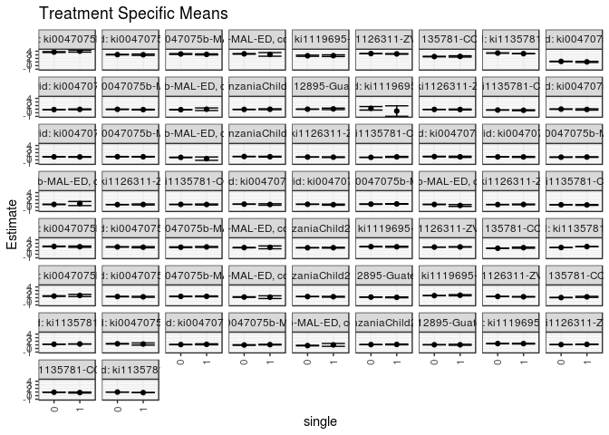

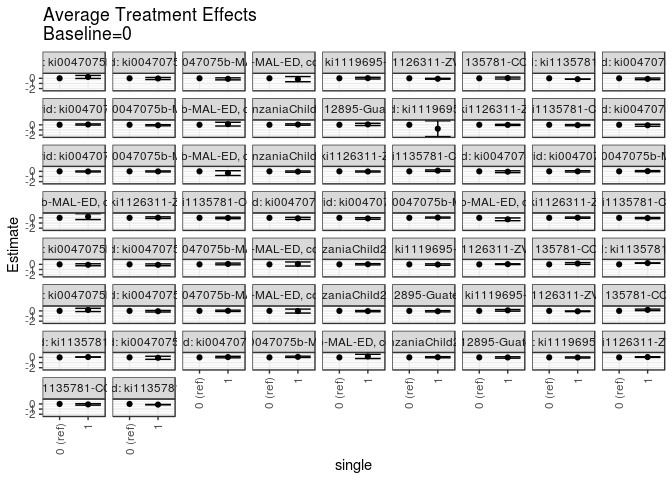

[figure not shown]

## Results Table

### Parameter: TSM

| agecat | studyid | country | intervention_level | baseline_level | estimate | ci_lower | ci_upper |
| --- | --- | --- | --- | --- | --- | --- | --- |
| 0-3 months | ki0047075b-MAL-ED | BRAZIL | 0 | NA | 3.7627570 | 3.6431974 | 3.8823166 |
| 0-3 months | ki0047075b-MAL-ED | BRAZIL | 1 | NA | 4.0253072 | 3.7558305 | 4.2947839 |
| 0-3 months | ki0047075b-MAL-ED | PERU | 0 | NA | 3.0562769 | 2.9853938 | 3.1271600 |
| 0-3 months | ki0047075b-MAL-ED | PERU | 1 | NA | 3.0193197 | 2.8284921 | 3.2101473 |
| 0-3 months | ki0047075b-MAL-ED | SOUTH AFRICA | 0 | NA | 3.2285246 | 3.1030967 | 3.3539526 |
| 0-3 months | ki0047075b-MAL-ED | SOUTH AFRICA | 1 | NA | 3.1176822 | 2.9660698 | 3.2692946 |
| 0-3 months | ki0047075b-MAL-ED | TANZANIA, UNITED REPUBLIC OF | 0 | NA | 3.2710348 | 3.1936231 | 3.3484464 |
| 0-3 months | ki0047075b-MAL-ED | TANZANIA, UNITED REPUBLIC OF | 1 | NA | 3.1054657 | 2.6067914 | 3.6041401 |
| 0-3 months | ki1119695-PROBIT | BELARUS | 0 | NA | 2.7432223 | 2.5744690 | 2.9119756 |
| 0-3 months | ki1119695-PROBIT | BELARUS | 1 | NA | 2.7689365 | 2.5363531 | 3.0015199 |
| 0-3 months | ki1126311-ZVITAMBO | ZIMBABWE | 0 | NA | 3.3438658 | 3.3227053 | 3.3650263 |
| 0-3 months | ki1126311-ZVITAMBO | ZIMBABWE | 1 | NA | 3.2513957 | 3.1666531 | 3.3361382 |
| 0-3 months | ki1135781-COHORTS | GUATEMALA | 0 | NA | 2.5162835 | 2.4469487 | 2.5856183 |
| 0-3 months | ki1135781-COHORTS | GUATEMALA | 1 | NA | 2.5590494 | 2.3852438 | 2.7328550 |
| 0-3 months | ki1135781-COHORTS | INDIA | 0 | NA | 3.4937576 | 3.4766632 | 3.5108521 |
| 0-3 months | ki1135781-COHORTS | INDIA | 1 | NA | 3.3233945 | 3.3058170 | 3.3409721 |
| 3-6 months | ki0047075b-MAL-ED | BRAZIL | 0 | NA | 2.1574240 | 2.0698552 | 2.2449927 |
| 3-6 months | ki0047075b-MAL-ED | BRAZIL | 1 | NA | 2.0787831 | 1.9027213 | 2.2548449 |
| 3-6 months | ki0047075b-MAL-ED | PERU | 0 | NA | 2.0261058 | 1.9543750 | 2.0978367 |
| 3-6 months | ki0047075b-MAL-ED | PERU | 1 | NA | 1.9391328 | 1.7749751 | 2.1032906 |
| 3-6 months | ki0047075b-MAL-ED | SOUTH AFRICA | 0 | NA | 1.9357570 | 1.8365908 | 2.0349232 |
| 3-6 months | ki0047075b-MAL-ED | SOUTH AFRICA | 1 | NA | 2.0137626 | 1.8816213 | 2.1459039 |
| 3-6 months | ki0047075b-MAL-ED | TANZANIA, UNITED REPUBLIC OF | 0 | NA | 1.8277484 | 1.7588679 | 1.8966290 |
| 3-6 months | ki0047075b-MAL-ED | TANZANIA, UNITED REPUBLIC OF | 1 | NA | 1.8977087 | 1.5100436 | 2.2853737 |
| 3-6 months | ki1066203-TanzaniaChild2 | TANZANIA, UNITED REPUBLIC OF | 0 | NA | 1.7908470 | 1.7532485 | 1.8284455 |
| 3-6 months | ki1066203-TanzaniaChild2 | TANZANIA, UNITED REPUBLIC OF | 1 | NA | 1.8087200 | 1.6895827 | 1.9278572 |
| 3-6 months | ki1119695-PROBIT | BELARUS | 0 | NA | 2.0909173 | 2.0243851 | 2.1574495 |
| 3-6 months | ki1119695-PROBIT | BELARUS | 1 | NA | 2.0610830 | 1.9219290 | 2.2002370 |
| 3-6 months | ki1126311-ZVITAMBO | ZIMBABWE | 0 | NA | 1.9731413 | 1.9526981 | 1.9935845 |
| 3-6 months | ki1126311-ZVITAMBO | ZIMBABWE | 1 | NA | 2.0147272 | 1.9410074 | 2.0884470 |

[output cut: 100 more lines]

### Parameter: E(Y)

| agecat | studyid | country | intervention_level | baseline_level | estimate | ci_lower | ci_upper |
| --- | --- | --- | --- | --- | --- | --- | --- |
| 0-3 months | ki0047075b-MAL-ED | BRAZIL | NA | NA | 3.7987014 | 3.6882619 | 3.9091408 |
| 0-3 months | ki0047075b-MAL-ED | PERU | NA | NA | 3.0519536 | 2.9854854 | 3.1184219 |
| 0-3 months | ki0047075b-MAL-ED | SOUTH AFRICA | NA | NA | 3.1817712 | 3.0847973 | 3.2787451 |
| 0-3 months | ki0047075b-MAL-ED | TANZANIA, UNITED REPUBLIC OF | NA | NA | 3.2644991 | 3.1874675 | 3.3415308 |
| 0-3 months | ki1119695-PROBIT | BELARUS | NA | NA | 2.7441602 | 2.5752798 | 2.9130407 |
| 0-3 months | ki1126311-ZVITAMBO | ZIMBABWE | NA | NA | 3.3380523 | 3.3175130 | 3.3585915 |
| 0-3 months | ki1135781-COHORTS | GUATEMALA | NA | NA | 2.5199342 | 2.4547928 | 2.5850757 |
| 0-3 months | ki1135781-COHORTS | INDIA | NA | NA | 3.4935018 | 3.4768279 | 3.5101758 |
| 3-6 months | ki0047075b-MAL-ED | BRAZIL | NA | NA | 2.1460815 | 2.0668679 | 2.2252951 |
| 3-6 months | ki0047075b-MAL-ED | PERU | NA | NA | 2.0156821 | 1.9494666 | 2.0818976 |
| 3-6 months | ki0047075b-MAL-ED | SOUTH AFRICA | NA | NA | 1.9704262 | 1.8897530 | 2.0510994 |
| 3-6 months | ki0047075b-MAL-ED | TANZANIA, UNITED REPUBLIC OF | NA | NA | 1.8300902 | 1.7622436 | 1.8979368 |
| 3-6 months | ki1066203-TanzaniaChild2 | TANZANIA, UNITED REPUBLIC OF | NA | NA | 1.7924482 | 1.7565918 | 1.8283046 |
| 3-6 months | ki1119695-PROBIT | BELARUS | NA | NA | 2.0898257 | 2.0242077 | 2.1554437 |
| 3-6 months | ki1126311-ZVITAMBO | ZIMBABWE | NA | NA | 1.9757282 | 1.9560142 | 1.9954421 |
| 3-6 months | ki1135781-COHORTS | GUATEMALA | NA | NA | 1.6651277 | 1.6196729 | 1.7105824 |
| 3-6 months | ki1135781-COHORTS | INDIA | NA | NA | 1.8572663 | 1.8432699 | 1.8712628 |
| 6-9 months | ki0047075b-MAL-ED | BRAZIL | NA | NA | 1.4831159 | 1.4026580 | 1.5635738 |
| 6-9 months | ki0047075b-MAL-ED | PERU | NA | NA | 1.3199965 | 1.2656612 | 1.3743319 |
| 6-9 months | ki0047075b-MAL-ED | SOUTH AFRICA | NA | NA | 1.3769258 | 1.3128158 | 1.4410357 |
| 6-9 months | ki0047075b-MAL-ED | TANZANIA, UNITED REPUBLIC OF | NA | NA | 1.1907556 | 1.1129385 | 1.2685726 |
| 6-9 months | ki1066203-TanzaniaChild2 | TANZANIA, UNITED REPUBLIC OF | NA | NA | 1.3243333 | 1.2877231 | 1.3609435 |
| 6-9 months | ki1112895-Guatemala BSC | GUATEMALA | NA | NA | 1.1723161 | 1.1280519 | 1.2165803 |
| 6-9 months | ki1119695-PROBIT | BELARUS | NA | NA | 1.5952397 | 1.5519431 | 1.6385362 |
| 6-9 months | ki1126311-ZVITAMBO | ZIMBABWE | NA | NA | 1.3472405 | 1.3281251 | 1.3663559 |
| 6-9 months | ki1135781-COHORTS | GUATEMALA | NA | NA | 1.0671566 | 1.0264887 | 1.1078244 |
| 6-9 months | ki1135781-COHORTS | INDIA | NA | NA | 1.1820108 | 1.1691162 | 1.1949053 |
| 9-12 months | ki0047075b-MAL-ED | BRAZIL | NA | NA | 1.2982559 | 1.2240694 | 1.3724425 |
| 9-12 months | ki0047075b-MAL-ED | PERU | NA | NA | 1.0985124 | 1.0475959 | 1.1494289 |
| 9-12 months | ki0047075b-MAL-ED | SOUTH AFRICA | NA | NA | 1.0143258 | 0.9494983 | 1.0791533 |
| 9-12 months | ki0047075b-MAL-ED | TANZANIA, UNITED REPUBLIC OF | NA | NA | 0.8131077 | 0.7319679 | 0.8942474 |
| 9-12 months | ki1066203-TanzaniaChild2 | TANZANIA, UNITED REPUBLIC OF | NA | NA | 1.0857505 | 1.0516744 | 1.1198266 |
| 9-12 months | ki1112895-Guatemala BSC | GUATEMALA | NA | NA | 1.0385849 | 0.9992705 | 1.0778993 |
| 9-12 months | ki1119695-PROBIT | BELARUS | NA | NA | 1.3641916 | 1.3090073 | 1.4193759 |
| 9-12 months | ki1126311-ZVITAMBO | ZIMBABWE | NA | NA | 1.0809511 | 1.0630344 | 1.0988678 |
| 9-12 months | ki1135781-COHORTS | GUATEMALA | NA | NA | 0.9381672 | 0.9020310 | 0.9743034 |
| 9-12 months | ki1135781-COHORTS | INDIA | NA | NA | 0.9844970 | 0.9705900 | 0.9984039 |
| 12-15 months | ki0047075b-MAL-ED | BRAZIL | NA | NA | 1.1421774 | 1.0831447 | 1.2012100 |
| 12-15 months | ki0047075b-MAL-ED | PERU | NA | NA | 0.8917280 | 0.8454370 | 0.9380189 |
| 12-15 months | ki0047075b-MAL-ED | SOUTH AFRICA | NA | NA | 0.9196294 | 0.8619875 | 0.9772714 |
| 12-15 months | ki0047075b-MAL-ED | TANZANIA, UNITED REPUBLIC OF | NA | NA | 0.8563558 | 0.7920248 | 0.9206869 |
| 12-15 months | ki1066203-TanzaniaChild2 | TANZANIA, UNITED REPUBLIC OF | NA | NA | 0.9319267 | 0.8950348 | 0.9688186 |
| 12-15 months | ki1112895-Guatemala BSC | GUATEMALA | NA | NA | 1.0088179 | 0.9480568 | 1.0695791 |
| 12-15 months | ki1119695-PROBIT | BELARUS | NA | NA | 1.2174129 | 0.7348696 | 1.6999562 |
| 12-15 months | ki1126311-ZVITAMBO | ZIMBABWE | NA | NA | 0.9206812 | 0.8937353 | 0.9476271 |
| 12-15 months | ki1135781-COHORTS | GUATEMALA | NA | NA | 0.7516138 | 0.7143731 | 0.7888544 |
| 15-18 months | ki0047075b-MAL-ED | BRAZIL | NA | NA | 1.0021114 | 0.9429996 | 1.0612232 |
| 15-18 months | ki0047075b-MAL-ED | PERU | NA | NA | 0.8534307 | 0.8111406 | 0.8957208 |
| 15-18 months | ki0047075b-MAL-ED | SOUTH AFRICA | NA | NA | 0.8871502 | 0.8344911 | 0.9398094 |
| 15-18 months | ki0047075b-MAL-ED | TANZANIA, UNITED REPUBLIC OF | NA | NA | 0.6867479 | 0.6257076 | 0.7477883 |
| 15-18 months | ki1066203-TanzaniaChild2 | TANZANIA, UNITED REPUBLIC OF | NA | NA | 0.9372014 | 0.8951355 | 0.9792674 |
| 15-18 months | ki1126311-ZVITAMBO | ZIMBABWE | NA | NA | 0.7979044 | 0.7680603 | 0.8277484 |
| 15-18 months | ki1135781-COHORTS | GUATEMALA | NA | NA | 0.7290606 | 0.6867384 | 0.7713829 |
| 18-21 months | ki0047075b-MAL-ED | BRAZIL | NA | NA | 0.9160758 | 0.8452655 | 0.9868862 |
| 18-21 months | ki0047075b-MAL-ED | PERU | NA | NA | 0.8414439 | 0.7967949 | 0.8860929 |
| 18-21 months | ki0047075b-MAL-ED | SOUTH AFRICA | NA | NA | 0.7821810 | 0.7266294 | 0.8377325 |
| 18-21 months | ki0047075b-MAL-ED | TANZANIA, UNITED REPUBLIC OF | NA | NA | 0.7437038 | 0.6761886 | 0.8112190 |
| 18-21 months | ki1126311-ZVITAMBO | ZIMBABWE | NA | NA | 0.6827825 | 0.6488968 | 0.7166681 |
| 18-21 months | ki1135781-COHORTS | GUATEMALA | NA | NA | 0.7317103 | 0.6914572 | 0.7719634 |
| 21-24 months | ki0047075b-MAL-ED | BRAZIL | NA | NA | 0.7961519 | 0.7521041 | 0.8401997 |
| 21-24 months | ki0047075b-MAL-ED | PERU | NA | NA | 0.7610506 | 0.7141593 | 0.8079419 |
| 21-24 months | ki0047075b-MAL-ED | SOUTH AFRICA | NA | NA | 0.8394950 | 0.7880175 | 0.8909725 |
| 21-24 months | ki0047075b-MAL-ED | TANZANIA, UNITED REPUBLIC OF | NA | NA | 0.7189328 | 0.6544287 | 0.7834368 |
| 21-24 months | ki1126311-ZVITAMBO | ZIMBABWE | NA | NA | 0.6904655 | 0.6523491 | 0.7285819 |
| 21-24 months | ki1135781-COHORTS | GUATEMALA | NA | NA | 0.6264917 | 0.5922491 | 0.6607344 |

### Parameter: ATE

| agecat | studyid | country | intervention_level | baseline_level | estimate | ci_lower | ci_upper |
| --- | --- | --- | --- | --- | --- | --- | --- |
| 0-3 months | ki0047075b-MAL-ED | BRAZIL | 0 | 0 | 0.0000000 | 0.0000000 | 0.0000000 |
| 0-3 months | ki0047075b-MAL-ED | BRAZIL | 1 | 0 | 0.2625502 | -0.0322585 | 0.5573590 |
| 0-3 months | ki0047075b-MAL-ED | PERU | 0 | 0 | 0.0000000 | 0.0000000 | 0.0000000 |
| 0-3 months | ki0047075b-MAL-ED | PERU | 1 | 0 | -0.0369572 | -0.2405244 | 0.1666099 |
| 0-3 months | ki0047075b-MAL-ED | SOUTH AFRICA | 0 | 0 | 0.0000000 | 0.0000000 | 0.0000000 |
| 0-3 months | ki0047075b-MAL-ED | SOUTH AFRICA | 1 | 0 | -0.1108424 | -0.3076126 | 0.0859277 |
| 0-3 months | ki0047075b-MAL-ED | TANZANIA, UNITED REPUBLIC OF | 0 | 0 | 0.0000000 | 0.0000000 | 0.0000000 |
| 0-3 months | ki0047075b-MAL-ED | TANZANIA, UNITED REPUBLIC OF | 1 | 0 | -0.1655690 | -0.6702161 | 0.3390780 |
| 0-3 months | ki1119695-PROBIT | BELARUS | 0 | 0 | 0.0000000 | 0.0000000 | 0.0000000 |
| 0-3 months | ki1119695-PROBIT | BELARUS | 1 | 0 | 0.0257142 | -0.1366676 | 0.1880960 |
| 0-3 months | ki1126311-ZVITAMBO | ZIMBABWE | 0 | 0 | 0.0000000 | 0.0000000 | 0.0000000 |
| 0-3 months | ki1126311-ZVITAMBO | ZIMBABWE | 1 | 0 | -0.0924702 | -0.1798147 | -0.0051256 |
| 0-3 months | ki1135781-COHORTS | GUATEMALA | 0 | 0 | 0.0000000 | 0.0000000 | 0.0000000 |
| 0-3 months | ki1135781-COHORTS | GUATEMALA | 1 | 0 | 0.0427659 | -0.1443590 | 0.2298908 |
| 0-3 months | ki1135781-COHORTS | INDIA | 0 | 0 | 0.0000000 | 0.0000000 | 0.0000000 |
| 0-3 months | ki1135781-COHORTS | INDIA | 1 | 0 | -0.1703631 | -0.1948823 | -0.1458439 |
| 3-6 months | ki0047075b-MAL-ED | BRAZIL | 0 | 0 | 0.0000000 | 0.0000000 | 0.0000000 |
| 3-6 months | ki0047075b-MAL-ED | BRAZIL | 1 | 0 | -0.0786409 | -0.2752777 | 0.1179959 |
| 3-6 months | ki0047075b-MAL-ED | PERU | 0 | 0 | 0.0000000 | 0.0000000 | 0.0000000 |
| 3-6 months | ki0047075b-MAL-ED | PERU | 1 | 0 | -0.0869730 | -0.2661184 | 0.0921724 |
| 3-6 months | ki0047075b-MAL-ED | SOUTH AFRICA | 0 | 0 | 0.0000000 | 0.0000000 | 0.0000000 |
| 3-6 months | ki0047075b-MAL-ED | SOUTH AFRICA | 1 | 0 | 0.0780056 | -0.0872072 | 0.2432184 |
| 3-6 months | ki0047075b-MAL-ED | TANZANIA, UNITED REPUBLIC OF | 0 | 0 | 0.0000000 | 0.0000000 | 0.0000000 |
| 3-6 months | ki0047075b-MAL-ED | TANZANIA, UNITED REPUBLIC OF | 1 | 0 | 0.0699602 | -0.3237767 | 0.4636971 |
| 3-6 months | ki1066203-TanzaniaChild2 | TANZANIA, UNITED REPUBLIC OF | 0 | 0 | 0.0000000 | 0.0000000 | 0.0000000 |
| 3-6 months | ki1066203-TanzaniaChild2 | TANZANIA, UNITED REPUBLIC OF | 1 | 0 | 0.0178730 | -0.1070564 | 0.1428023 |
| 3-6 months | ki1119695-PROBIT | BELARUS | 0 | 0 | 0.0000000 | 0.0000000 | 0.0000000 |
| 3-6 months | ki1119695-PROBIT | BELARUS | 1 | 0 | -0.0298343 | -0.1677637 | 0.1080951 |
| 3-6 months | ki1126311-ZVITAMBO | ZIMBABWE | 0 | 0 | 0.0000000 | 0.0000000 | 0.0000000 |
| 3-6 months | ki1126311-ZVITAMBO | ZIMBABWE | 1 | 0 | 0.0415859 | -0.0349160 | 0.1180877 |

[output cut: 100 more lines]

### Parameter: PAR

| agecat | studyid | country | intervention_level | baseline_level | estimate | ci_lower | ci_upper |
| --- | --- | --- | --- | --- | --- | --- | --- |
| 0-3 months | ki0047075b-MAL-ED | BRAZIL | 0 | NA | 0.0359444 | -0.0066743 | 0.0785630 |
| 0-3 months | ki0047075b-MAL-ED | PERU | 0 | NA | -0.0043233 | -0.0281799 | 0.0195333 |
| 0-3 months | ki0047075b-MAL-ED | SOUTH AFRICA | 0 | NA | -0.0467534 | -0.1300808 | 0.0365739 |
| 0-3 months | ki0047075b-MAL-ED | TANZANIA, UNITED REPUBLIC OF | 0 | NA | -0.0065356 | -0.0268926 | 0.0138214 |
| 0-3 months | ki1119695-PROBIT | BELARUS | 0 | NA | 0.0009380 | -0.0050815 | 0.0069575 |
| 0-3 months | ki1126311-ZVITAMBO | ZIMBABWE | 0 | NA | -0.0058135 | -0.0113269 | -0.0003001 |
| 0-3 months | ki1135781-COHORTS | GUATEMALA | 0 | NA | 0.0036507 | -0.0123757 | 0.0196772 |
| 0-3 months | ki1135781-COHORTS | INDIA | 0 | NA | -0.0002558 | -0.0008974 | 0.0003858 |
| 3-6 months | ki0047075b-MAL-ED | BRAZIL | 0 | NA | -0.0113424 | -0.0399522 | 0.0172673 |
| 3-6 months | ki0047075b-MAL-ED | PERU | 0 | NA | -0.0104237 | -0.0321610 | 0.0113136 |
| 3-6 months | ki0047075b-MAL-ED | SOUTH AFRICA | 0 | NA | 0.0346692 | -0.0389210 | 0.1082593 |
| 3-6 months | ki0047075b-MAL-ED | TANZANIA, UNITED REPUBLIC OF | 0 | NA | 0.0023418 | -0.0109343 | 0.0156179 |
| 3-6 months | ki1066203-TanzaniaChild2 | TANZANIA, UNITED REPUBLIC OF | 0 | NA | 0.0016012 | -0.0095937 | 0.0127961 |
| 3-6 months | ki1119695-PROBIT | BELARUS | 0 | NA | -0.0010916 | -0.0062618 | 0.0040786 |
| 3-6 months | ki1126311-ZVITAMBO | ZIMBABWE | 0 | NA | 0.0025869 | -0.0021786 | 0.0073523 |
| 3-6 months | ki1135781-COHORTS | GUATEMALA | 0 | NA | 0.0154115 | -0.0011280 | 0.0319511 |
| 3-6 months | ki1135781-COHORTS | INDIA | 0 | NA | 0.0004252 | -0.0005090 | 0.0013594 |
| 6-9 months | ki0047075b-MAL-ED | BRAZIL | 0 | NA | 0.0253777 | -0.0200186 | 0.0707740 |
| 6-9 months | ki0047075b-MAL-ED | PERU | 0 | NA | -0.0086972 | -0.0277428 | 0.0103484 |
| 6-9 months | ki0047075b-MAL-ED | SOUTH AFRICA | 0 | NA | 0.0060488 | -0.0529042 | 0.0650017 |
| 6-9 months | ki0047075b-MAL-ED | TANZANIA, UNITED REPUBLIC OF | 0 | NA | -0.0009762 | -0.0113015 | 0.0093491 |
| 6-9 months | ki1066203-TanzaniaChild2 | TANZANIA, UNITED REPUBLIC OF | 0 | NA | -0.0039848 | -0.0149870 | 0.0070174 |
| 6-9 months | ki1112895-Guatemala BSC | GUATEMALA | 0 | NA | -0.0074513 | -0.0204985 | 0.0055958 |
| 6-9 months | ki1119695-PROBIT | BELARUS | 0 | NA | 0.0039115 | -0.0023970 | 0.0102200 |
| 6-9 months | ki1126311-ZVITAMBO | ZIMBABWE | 0 | NA | -0.0045410 | -0.0091145 | 0.0000325 |
| 6-9 months | ki1135781-COHORTS | GUATEMALA | 0 | NA | 0.0186976 | 0.0033450 | 0.0340501 |
| 6-9 months | ki1135781-COHORTS | INDIA | 0 | NA | 0.0001322 | -0.0004019 | 0.0006663 |
| 9-12 months | ki0047075b-MAL-ED | BRAZIL | 0 | NA | -0.0103210 | -0.0523382 | 0.0316962 |
| 9-12 months | ki0047075b-MAL-ED | PERU | 0 | NA | 0.0076235 | -0.0107957 | 0.0260427 |
| 9-12 months | ki0047075b-MAL-ED | SOUTH AFRICA | 0 | NA | 0.0491825 | -0.0095369 | 0.1079019 |
| 9-12 months | ki0047075b-MAL-ED | TANZANIA, UNITED REPUBLIC OF | 0 | NA | 0.0059388 | -0.0076038 | 0.0194815 |
| 9-12 months | ki1066203-TanzaniaChild2 | TANZANIA, UNITED REPUBLIC OF | 0 | NA | 0.0033290 | -0.0069204 | 0.0135783 |
| 9-12 months | ki1112895-Guatemala BSC | GUATEMALA | 0 | NA | -0.0012672 | -0.0154161 | 0.0128818 |
| 9-12 months | ki1119695-PROBIT | BELARUS | 0 | NA | -0.0005201 | -0.0044388 | 0.0033986 |
| 9-12 months | ki1126311-ZVITAMBO | ZIMBABWE | 0 | NA | 0.0037847 | -0.0004317 | 0.0080010 |
| 9-12 months | ki1135781-COHORTS | GUATEMALA | 0 | NA | -0.0087855 | -0.0225462 | 0.0049752 |
| 9-12 months | ki1135781-COHORTS | INDIA | 0 | NA | -0.0002844 | -0.0009406 | 0.0003717 |
| 12-15 months | ki0047075b-MAL-ED | BRAZIL | 0 | NA | -0.0151740 | -0.0369120 | 0.0065640 |
| 12-15 months | ki0047075b-MAL-ED | PERU | 0 | NA | 0.0082700 | -0.0070229 | 0.0235628 |
| 12-15 months | ki0047075b-MAL-ED | SOUTH AFRICA | 0 | NA | -0.0373594 | -0.0908005 | 0.0160817 |
| 12-15 months | ki0047075b-MAL-ED | TANZANIA, UNITED REPUBLIC OF | 0 | NA | 0.0039768 | -0.0077987 | 0.0157522 |
| 12-15 months | ki1066203-TanzaniaChild2 | TANZANIA, UNITED REPUBLIC OF | 0 | NA | 0.0046635 | -0.0070918 | 0.0164188 |
| 12-15 months | ki1112895-Guatemala BSC | GUATEMALA | 0 | NA | 0.0097622 | -0.0181351 | 0.0376595 |
| 12-15 months | ki1119695-PROBIT | BELARUS | 0 | NA | -0.0187109 | -0.0669181 | 0.0294963 |
| 12-15 months | ki1126311-ZVITAMBO | ZIMBABWE | 0 | NA | -0.0008381 | -0.0077671 | 0.0060909 |
| 12-15 months | ki1135781-COHORTS | GUATEMALA | 0 | NA | -0.0062891 | -0.0194648 | 0.0068865 |
| 15-18 months | ki0047075b-MAL-ED | BRAZIL | 0 | NA | -0.0102557 | -0.0334643 | 0.0129529 |
| 15-18 months | ki0047075b-MAL-ED | PERU | 0 | NA | -0.0032455 | -0.0154080 | 0.0089170 |
| 15-18 months | ki0047075b-MAL-ED | SOUTH AFRICA | 0 | NA | -0.0078198 | -0.0547439 | 0.0391043 |
| 15-18 months | ki0047075b-MAL-ED | TANZANIA, UNITED REPUBLIC OF | 0 | NA | -0.0096238 | -0.0246132 | 0.0053656 |
| 15-18 months | ki1066203-TanzaniaChild2 | TANZANIA, UNITED REPUBLIC OF | 0 | NA | -0.0054126 | -0.0179477 | 0.0071225 |
| 15-18 months | ki1126311-ZVITAMBO | ZIMBABWE | 0 | NA | -0.0021455 | -0.0085487 | 0.0042578 |
| 15-18 months | ki1135781-COHORTS | GUATEMALA | 0 | NA | 0.0112942 | -0.0016015 | 0.0241899 |
| 18-21 months | ki0047075b-MAL-ED | BRAZIL | 0 | NA | -0.0086877 | -0.0317952 | 0.0144198 |
| 18-21 months | ki0047075b-MAL-ED | PERU | 0 | NA | -0.0010327 | -0.0173444 | 0.0152790 |
| 18-21 months | ki0047075b-MAL-ED | SOUTH AFRICA | 0 | NA | 0.0145531 | -0.0344627 | 0.0635689 |
| 18-21 months | ki0047075b-MAL-ED | TANZANIA, UNITED REPUBLIC OF | 0 | NA | 0.0071438 | -0.0105775 | 0.0248651 |
| 18-21 months | ki1126311-ZVITAMBO | ZIMBABWE | 0 | NA | 0.0019847 | -0.0068755 | 0.0108449 |
| 18-21 months | ki1135781-COHORTS | GUATEMALA | 0 | NA | -0.0017125 | -0.0142340 | 0.0108090 |
| 21-24 months | ki0047075b-MAL-ED | BRAZIL | 0 | NA | -0.0117073 | -0.0376302 | 0.0142157 |
| 21-24 months | ki0047075b-MAL-ED | PERU | 0 | NA | -0.0141085 | -0.0339519 | 0.0057349 |
| 21-24 months | ki0047075b-MAL-ED | SOUTH AFRICA | 0 | NA | 0.0237379 | -0.0231354 | 0.0706112 |
| 21-24 months | ki0047075b-MAL-ED | TANZANIA, UNITED REPUBLIC OF | 0 | NA | -0.0083410 | -0.0185922 | 0.0019102 |
| 21-24 months | ki1126311-ZVITAMBO | ZIMBABWE | 0 | NA | 0.0019852 | -0.0048057 | 0.0087760 |
| 21-24 months | ki1135781-COHORTS | GUATEMALA | 0 | NA | -0.0045817 | -0.0168874 | 0.0077239 |